# Fertility and Wealth: Causal Evidence for Latin America

Work in progress

Edison Choque Sanchez

30/07/2022

# 1. Introduction

In this file we show the process to estimate the causal effect from fertility to household wealth. This process has three stages. First, we import the data base and explore it, but also we generate a subset of the data base because women are the group of analysis. Second, all the variable of interest should be created. For instance most of them should be transformed into the correct format. Finally, we show the result according to the model.

# 2. DHS program data

DHS surveys collect primary data using several types of questionnaires. A household questionnaire is used to collect information on characteristics of the household’s dwelling unit, and data related to the height and weight for women and children in the household. It is also used to identify members of the household who are eligible for an individual interview. Eligible respondents are then interviewed using an individual questionnaire.

In a majority of DHS surveys eligible individuals include women of reproductive age (15-49) and men age 15-59, or in some cases 15-54. In some countries only women are interviewed. Individual questionnaires include information on fertility, family planning and maternal and child health.

We use the individual record data. It mean that all women between 15 - 49 years old were interviewed. You can visit the following website to know about DHS program and data. [DHS program](https://dhsprogram.com/data/Getting-Started.cfm)

## Loading data

```r
setwd("I:/Mi unidad/Consultorias/Gus_Canavire/ProyectoDHS")
dir()
```

```
##  [1] "base_ir1.DTA"         "base_ir2.DTA"         "Data"
##  [4] "everything.Rdata"     "Export"               "Info"
##  [7] "ProyectoDHS.Rproj"    "Script"               "weak_test_model1.PNG"
## [10] "weak_test_model2.PNG"
```

```r
load("everything.Rdata")
```

In order to study specific data. First, we use two databases from 6 Latin American countries. These are Bolivia, Colombia, Republica Dominicana, Guyana, Honduras, and Haiti. This data is collected between 2005 to 2009 according to the phase 5 - DHS program.

To know the definition for the most of the variables, we suggest downloading the pdf files from the following link: [Files](https://dhsprogram.com/publications/publication-dhsg4-dhs-questionnaires-and-manuals.cfm). Once you enter to the link, download two pdf files: DHS-V Recode Manual and DHS-V Recode Map. In both, you can find more information about the variables and data structure.

This presentation keeps on with the third section which shows the description of the variables. We explain the principal results of the econometrics models in the fourth section. Finally, we present the principal conclusion and recommendations.

# 3. Description of the Database

## Model 1: Infertility shock

In this model, the outcome/dependent variable is the wealth index score and the endogenous variable is the total number of children ever born. The database considers women with o without children.

First, we explore the dependent variable which is the Wealth index factor score:

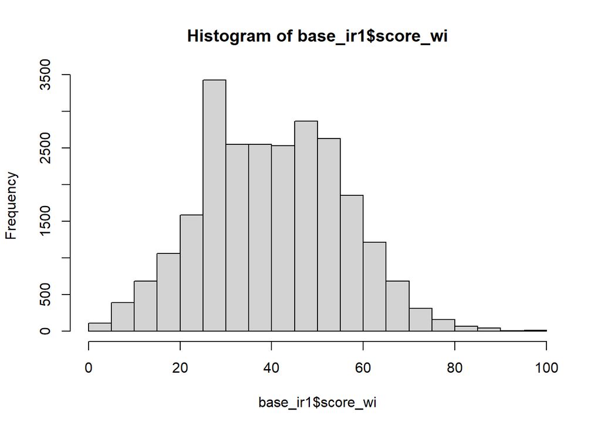

```r
hist(base_ir1$score_wi)
```

```r
quantile(base_ir1$score_wi)
```

```
##        0%       25%       50%       75%      100%
##   0.52486  28.35195  40.01850  51.39701 100.00000
```

```r
summary(base_ir1$score_wi)
```

```
##     Min.  1st Qu.   Median     Mean  3rd Qu.     Max.
##   0.5249  28.3519  40.0185  40.2358  51.3970 100.0000
```

Second, we describe the endogenous variable that is fertility, which is the number of living children. But also, we can define this variable in different ways. See some of these options:

```r
#All Sample
summarytools::freq(base_ir1$total_children) # Number of children ever born
```

```
## Frequencies
## base_ir1$total_children
## Type: Integer
##
##                Freq    % Valid   % Valid Cum.    % Total   % Total Cum.
## ----------- ------- ---------- -------------- ---------- --------------
##           0    3418    13.8090        13.8090    13.8090        13.8090
##           1    4561    18.4268        32.2358    18.4268        32.2358
##           2    4856    19.6186        51.8544    19.6186        51.8544
##           3    3469    14.0150        65.8694    14.0150        65.8694
##           4    2418     9.7689        75.6383     9.7689        75.6383
##           5    1761     7.1146        82.7529     7.1146        82.7529
##           6    1273     5.1430        87.8959     5.1430        87.8959
##           7     928     3.7492        91.6451     3.7492        91.6451
##           8     783     3.1634        94.8085     3.1634        94.8085
##           9     504     2.0362        96.8447     2.0362        96.8447
##          10     367     1.4827        98.3274     1.4827        98.3274
##          11     206     0.8323        99.1597     0.8323        99.1597
##          12     121     0.4888        99.6485     0.4888        99.6485
##          13      59     0.2384        99.8869     0.2384        99.8869
##          14      16     0.0646        99.9515     0.0646        99.9515
##          15       5     0.0202        99.9717     0.0202        99.9717
##          16       4     0.0162        99.9879     0.0162        99.9879
##          18       2     0.0081        99.9960     0.0081        99.9960
##          20       1     0.0040       100.0000     0.0040       100.0000
##        <NA>       0                               0.0000       100.0000
##       Total   24752   100.0000       100.0000   100.0000       100.0000
```

Third, we describe the instrument for the endogenous variable. This instrument is defined in two ways. Both are self-declarations of infertility for women.

1. when the question is: Main reason not to use meth, and the answer is Subfecund, infecund (infertility1).
2. when the question is: Fertility preference, and the answer is: Declared infecund (infertility2).

```r
base_ir1 %>% group_by(infertility1) %>%  summarise(mean = mean(total_children), n = n()) #total sample
```

```
## # A tibble: 2 × 3
##   infertility1  mean     n
##          <dbl> <dbl> <int>
## 1            0  3.08 23107
## 2            1  3.32  1645
```

```r
base_ir1 %>% group_by(infertility2) %>%  summarise(mean = mean(total_children), n = n())#total sample
```

```
## # A tibble: 2 × 3
##   infertility2  mean     n
##          <dbl> <dbl> <int>
## 1            0  3.08 22895
## 2            1  3.31  1857
```

```r
#instrument is defined as infertility1 or  infertility2
#Bolivia
base_ir1 %>% filter(v000=="BO5") %>% group_by(age_group,instrument) %>%  summarise(mean = mean(total_children), n = n())
```

```
## # A tibble: 14 × 4
## # Groups:   age_group [7]
##    age_group instrument  mean     n
##    <chr>          <dbl> <dbl> <int>
##  1 15-19              0 0.6     310
##  2 15-19              1 0.333     3
##  3 20-24              0 1.45    559
##  4 20-24              1 0.667     3
##  5 25-29              0 2.43    748
##  6 25-29              1 1.73     15
##  7 30-34              0 3.29    650
##  8 30-34              1 1.69     16
##  9 35-39              0 4.20    642
## 10 35-39              1 2.04     51
## 11 40-44              0 5.11    586
## 12 40-44              1 3.47     98
## 13 45-49              0 5.62    742
## 14 45-49              1 4.47    234
```

```r
#Colombia
base_ir1 %>% filter(v000=="CO4") %>% group_by(age_group,instrument) %>%  summarise(mean = mean(total_children), n = n())
```

```
## # A tibble: 14 × 4
## # Groups:   age_group [7]
##    age_group instrument  mean     n
##    <chr>          <dbl> <dbl> <int>
##  1 15-19              0 0.597   308
##  2 15-19              1 0         1
##  3 20-24              0 1.15    725
##  4 20-24              1 0         6
##  5 25-29              0 1.71    801
##  6 25-29              1 0.591    22
##  7 30-34              0 2.22    815
##  8 30-34              1 1.37     49
##  9 35-39              0 2.64    814
## 10 35-39              1 1.88     93
## 11 40-44              0 3.09    838
## 12 40-44              1 2.03    148
## 13 45-49              0 3.38    893
## 14 45-49              1 2.78    369
```

```r
#Republica Dominicana
base_ir1 %>% filter(v000=="DR5") %>% group_by(age_group,instrument) %>%  summarise(mean = mean(total_children), n = n())
```

```
## # A tibble: 14 × 4
## # Groups:   age_group [7]
##    age_group instrument  mean     n
##    <chr>          <dbl> <dbl> <int>
##  1 15-19              0 0.628   387
##  2 15-19              1 0.667     3
##  3 20-24              0 1.34    767
##  4 20-24              1 1.25      8
##  5 25-29              0 2.00    876
##  6 25-29              1 1.54     13
##  7 30-34              0 2.36    704
##  8 30-34              1 2.11     37
##  9 35-39              0 2.88    531
## 10 35-39              1 2.10     58
## 11 40-44              0 3.36    477
## 12 40-44              1 2       117
## 13 45-49              0 3.78    381
## 14 45-49              1 2.45    160
```

```r
#Guyana
base_ir1 %>% filter(v000=="GY5") %>% group_by(age_group,instrument) %>%  summarise(mean = mean(total_children), n = n())
```

```
## # A tibble: 11 × 4
## # Groups:   age_group [7]
##    age_group instrument  mean     n
##    <chr>          <dbl> <dbl> <int>
##  1 15-19              0  1.16    61
##  2 20-24              0  1.50   183
##  3 25-29              0  2.38   242
##  4 30-34              0  3.01   262
##  5 30-34              1  2        2
##  6 35-39              0  3.36   314
##  7 35-39              1  1.7     10
##  8 40-44              0  3.73   311
##  9 40-44              1  3.55    20
## 10 45-49              0  3.94   318
## 11 45-49              1  3.21    39
```

```r
#Honduras
base_ir1 %>% filter(v000=="HN5") %>% group_by(age_group,instrument) %>%  summarise(mean = mean(total_children), n = n())
```

```
## # A tibble: 14 × 4
## # Groups:   age_group [7]
##    age_group instrument  mean     n
##    <chr>          <dbl> <dbl> <int>
##  1 15-19              0 0.638   260
##  2 15-19              1 0         1
##  3 20-24              0 1.65    650
##  4 20-24              1 0.75      4
##  5 25-29              0 2.62    786
##  6 25-29              1 1.28     18
##  7 30-34              0 3.79    656
##  8 30-34              1 1.65     23
##  9 35-39              0 4.91    599
## 10 35-39              1 2.02     50
## 11 40-44              0 5.92    492
## 12 40-44              1 3.90     72
## 13 45-49              0 6.57    538
## 14 45-49              1 5.97    190
```

```r
#Haiti
base_ir1 %>% filter(v000=="HT5") %>% group_by(age_group,instrument) %>%  summarise(mean = mean(total_children), n = n())
```

```
## # A tibble: 12 × 4
## # Groups:   age_group [7]
##    age_group instrument  mean     n
##    <chr>          <dbl> <dbl> <int>
##  1 15-19              0 0.709    86
##  2 20-24              0 1.41    369
##  3 25-29              0 2.34    588
##  4 25-29              1 0.667     3
##  5 30-34              0 3.49    600
##  6 30-34              1 3.5       2
##  7 35-39              0 4.67    633
##  8 35-39              1 2        15
##  9 40-44              0 5.84    548
## 10 40-44              1 3.65     57
## 11 45-49              0 6.12    519
## 12 45-49              1 5.07    173
```

Finally, we describe the rest of the variables for model 1.

```r
summary(base_ir1$age) # Current age - respondent
```

```
##    Min. 1st Qu.  Median    Mean 3rd Qu.    Max.
##   15.00   26.00   34.00   34.08   42.00   49.00
```

```r
summary(base_ir1$years_education) #  Education in single years
```

```
##    Min. 1st Qu.  Median    Mean 3rd Qu.    Max.
##    0.00    2.00    6.00    6.51   11.00   99.00
```

```r
table(base_ir1$urban) # Type of place of residence
```

```
##
##     0     1
## 11529 13223
```

## Model 2: Twins

In this econometric model, the outcome variable is the same as in model 1. Also, the endogenous variable is the same. But in this case, the database changed because now we consider women with equal or more than one child.

Now, we can describe the instrumental variable for model 2. This is defined as *twin*. We assume that mothers with the experience of having twins have to raise extra children. That is why it works as a good instrument to measure the causal effect.

In the next chunk, we show a summary table for the mean of the number of total children according to mothers who had twins and the ones that did not. The result shows that this average is lower for the mothers who never had twins than the ones who did, so that makes sense.

```r
#Bolivia
base_ir2 %>% filter(v000=="BO5") %>% group_by(twin) %>%  summarise(mean = mean(total_children), n = n())
```

```
## # A tibble: 2 × 3
##    twin  mean     n
##   <dbl> <dbl> <int>
## 1     0  3.71  9584
## 2     1  6.34   236
```

```r
#Colombia
base_ir2 %>% filter(v000=="CO4") %>% group_by(twin) %>%  summarise(mean = mean(total_children), n = n())
```

```
## # A tibble: 2 × 3
##    twin  mean     n
##   <dbl> <dbl> <int>
## 1     0  2.92 19499
## 2     1  4.85   453
```

```r
#Rep. Dominicana
base_ir2 %>% filter(v000=="DR5") %>% group_by(twin) %>%  summarise(mean = mean(total_children), n = n())
```

```
## # A tibble: 2 × 3
##    twin  mean     n
##   <dbl> <dbl> <int>
## 1     0  3.14 15212
## 2     1  4.95   516
```

```r
#Guyana
base_ir2 %>% filter(v000=="GY5") %>% group_by(twin) %>%  summarise(mean = mean(total_children), n = n())
```

```
## # A tibble: 2 × 3
##    twin  mean     n
##   <dbl> <dbl> <int>
## 1     0  3.41  2662
## 2     1  5.39    66
```

```r
#Honduras
base_ir2 %>% filter(v000=="HN5") %>% group_by(twin) %>%  summarise(mean = mean(total_children), n = n())
```

```
## # A tibble: 2 × 3
##    twin  mean     n
##   <dbl> <dbl> <int>
## 1     0  3.98 10250
## 2     1  6.86   343
```

```r
#Haiti
base_ir2 %>% filter(v000=="HT5") %>% group_by(twin) %>%  summarise(mean = mean(total_children), n = n())
```

```
## # A tibble: 2 × 3
##    twin  mean     n
##   <dbl> <dbl> <int>
## 1     0  4.22  4447
## 2     1  7      262
```

Finally, we present the description for the rest of the variables for model 2.

```r
summary(base_ir2$age) #Current age - respondent
```

```
##    Min. 1st Qu.  Median    Mean 3rd Qu.    Max.
##   14.00   28.00   35.00   34.87   42.00   49.00
```

```r
summary(base_ir2$age_firstbirth) # Age of respondent at 1st birth
```

```
##    Min. 1st Qu.  Median    Mean 3rd Qu.    Max.
##    9.00   17.00   19.00   19.99   22.00   46.00
```

```r
summary(base_ir2$years_education) # Education in single years
```

```
##    Min. 1st Qu.  Median    Mean 3rd Qu.    Max.
##   0.000   3.000   6.000   6.869  11.000  99.000
```

```r
summarytools::freq(base_ir2$urban) # 1 urbano - 0 rural
```

```
## Frequencies
## base_ir2$urban
## Type: Numeric
##
##                Freq   % Valid   % Valid Cum.   % Total   % Total Cum.
## ----------- ------- --------- -------------- --------- --------------
##           0   27061     42.60          42.60     42.60          42.60
##           1   36469     57.40         100.00     57.40         100.00
##        <NA>       0                               0.00         100.00
##       Total   63530    100.00         100.00    100.00         100.00
```

# 4. Econometrics Models

## Model 1: Infertility shock

Definition of the dependent variables:

- score_wi: Wealth index factor score standardized between 0 - 100

Definition of the endogenous variables:

- total_children: total children ever born

Definition of the instrument:

- instrument: infertility1 or infertility2 defined above

Control variables are defined as follow:

- age: Current age - respondent
- year_education: Education in single years
- urban: the responded live in urban area

```r
m1_iv1w_bo5 <- ivreg(score_wi~ total_children + age + years_education + urban
                    |instrument + age + years_education + urban, data = base_ir1,
                    subset = v000 %in% "BO5", weights = v005)

m1_iv1w_co4<- ivreg(score_wi~ total_children + age + years_education + urban
                   |instrument + age + years_education + urban, data = base_ir1,
                subset = v000 %in% "CO4", weights = v005)

m1_iv1w_dr5<- ivreg(score_wi~ total_children + age + years_education + urban
                   |instrument + age + years_education + urban, data = base_ir1,
                subset = v000 %in% "DR5", weights = v005)

m1_iv1w_gy5 <- ivreg(score_wi~ total_children + age + years_education + urban
                    |instrument + age + years_education + urban, data = base_ir1,
                subset = v000 %in% "GY5", weights = v005)

m1_iv1w_hn5 <- ivreg(score_wi~ total_children + age + years_education + urban
                    |instrument + age + years_education + urban, data = base_ir1,
                subset = v000 %in% "HN5", weights = v005)

m1_iv1w_ht5 <- ivreg(score_wi~ total_children + age + years_education + urban
                    |instrument + age + years_education + urban, data = base_ir1,
                subset = v000 %in% "HT5", weights = v005)

tab_model(m1_iv1w_bo5, m1_iv1w_co4, m1_iv1w_dr5,m1_iv1w_gy5,m1_iv1w_hn5,m1_iv1w_ht5
          ,collapse.ci = TRUE, p.style = "stars",dv.labels = c("Bolivia", "Colombia",
            "Rep.Dominicana", "Guyana","Honduras","Haiti"))
```

Bolivia

Colombia

Rep.Dominicana

Guyana

Honduras

Haiti

Predictors

Estimates

Estimates

Estimates

Estimates

Estimates

Estimates

(Intercept)

15.35 ***  
(14.23 – 16.46)

13.80 ***  
(11.06 – 16.54)

19.40 ***  
(17.48 – 21.32)

31.57 ***  
(28.71 – 34.44)

21.74 ***  
(20.58 – 22.90)

28.51 ***  
(26.74 – 30.27)

total children

-1.35 ***  
(-1.90 – -0.80)

-5.09 ***  
(-6.83 – -3.36)

-1.76 *  
(-3.14 – -0.38)

-1.40  
(-5.60 – 2.80)

-0.88 *  
(-1.59 – -0.17)

0.41  
(-0.51 – 1.33)

age

0.39 ***  
(0.31 – 0.47)

0.69 ***  
(0.56 – 0.82)

0.43 ***  
(0.33 – 0.53)

0.37 *  
(0.01 – 0.72)

0.29 ***  
(0.17 – 0.42)

0.05  
(-0.10 – 0.20)

years education

0.80 ***  
(0.68 – 0.91)

0.56 ***  
(0.28 – 0.84)

0.96 ***  
(0.83 – 1.10)

0.16  
(-0.04 – 0.36)

1.50 ***  
(1.32 – 1.68)

1.39 ***  
(1.23 – 1.54)

urban

18.19 ***  
(17.50 – 18.88)

15.54 ***  
(14.07 – 17.00)

10.33 ***  
(9.35 – 11.31)

9.39 ***  
(6.11 – 12.68)

14.41 ***  
(13.55 – 15.26)

17.49 ***  
(16.19 – 18.79)

Observations

4657

5882

4519

1762

4339

3593

R<sup>2</sup> / R<sup>2</sup> adjusted

0.702 / 0.702

0.470 / 0.469

0.405 / 0.405

0.250 / 0.248

0.663 / 0.662

0.552 / 0.552

- p<0.05 ** p<0.01 *** p<0.001

The principal results show that the causal effect from fertility to the score of wealth index in negative for Bolivia, Colombia, Rep. Dominicana and Honduras. These coeficientes are between 0.88 and 5.09 for each child. Also, we can see that these results are statistically significant.

It is important to notice that the causal effect from the *total_children* variable is small in average for each children, except for Colombia. Moreover, notice that we applied the sample weigth for each sample separately in order to have a country implication for the results.

According to the test for weak instrument, we reject the null hypothesis for the countries we mention before. It means that the instruments are good enough to predict a causal effect.

```r
#Endogeneity test
summary(m1_iv1w_bo5, diagnostics=TRUE)$diagnostics
```

```
##                  df1  df2  statistic      p-value
## Weak instruments   1 4652 200.922504 1.105604e-44
## Wu-Hausman         1 4651   3.816031 5.082422e-02
## Sargan             0   NA         NA           NA
```

```r
summary(m1_iv1w_co4, diagnostics=TRUE)$diagnostics
```

```
##                  df1  df2 statistic      p-value
## Weak instruments   1 5877  60.53235 8.492868e-15
## Wu-Hausman         1 5876  25.73105 4.045110e-07
## Sargan             0   NA        NA           NA
```

```r
summary(m1_iv1w_dr5, diagnostics=TRUE)$diagnostics
```

```
##                  df1  df2    statistic      p-value
## Weak instruments   1 4514 113.72479462 3.066069e-26
## Wu-Hausman         1 4513   0.02684383 8.698638e-01
## Sargan             0   NA           NA           NA
```

```r
summary(m1_iv1w_gy5, diagnostics=TRUE)$diagnostics
```

```
##                  df1  df2 statistic     p-value
## Weak instruments   1 1757 8.5077433 0.003581264
## Wu-Hausman         1 1756 0.2550043 0.613636595
## Sargan             0   NA        NA          NA
```

```r
summary(m1_iv1w_hn5, diagnostics=TRUE)$diagnostics
```

```
##                  df1  df2    statistic      p-value
## Weak instruments   1 4334 1.390043e+02 1.329628e-31
## Wu-Hausman         1 4333 2.024829e-03 9.641109e-01
## Sargan             0   NA           NA           NA
```

```r
summary(m1_iv1w_ht5, diagnostics=TRUE)$diagnostics
```

```
##                  df1  df2 statistic      p-value
## Weak instruments   1 3588 108.68859 4.318929e-25
## Wu-Hausman         1 3587  13.33285 2.645196e-04
## Sargan             0   NA        NA           NA
```

## Model 2: Twins

Definition of the dependent variables:

- score_wi: Wealth index factor score standardized

Definition of the endogenous variables:

- total_children: total children ever born

Control variables are defined as follow:

- age: Current age - respondent
- age_firstbirth: Age of respondent at 1st birth
- year_education: Education in single years
- urban: the responded live in urban area

```r
m2_iv1w_bo5 <- ivreg(score_wi~ total_children + age + age_firstbirth + years_education + urban
                    |twin + age+ age_firstbirth + years_education + urban, data = base_ir2,
                    subset = v000 %in% "BO5", weights = v005)

m2_iv1w_co4<- ivreg(score_wi~ total_children + age + age_firstbirth + years_education + urban
                   |twin + age+ age_firstbirth + years_education + urban, data = base_ir2,
                   subset = v000 %in% "CO4", weights = v005)

m2_iv1w_dr5<- ivreg(score_wi~ total_children + age+ age_firstbirth + years_education + urban
                   |twin + age+ age_firstbirth + years_education + urban, data = base_ir2,
                   subset = v000 %in% "DR5", weights = v005)

m2_iv1w_gy5 <- ivreg(score_wi~ total_children + age+ age_firstbirth + years_education + urban
                    |twin + age+ age_firstbirth + years_education + urban, data = base_ir2,
                    subset = v000 %in% "GY5", weights = v005)

m2_iv1w_hn5 <- ivreg(score_wi~ total_children + age+ age_firstbirth + years_education + urban
                    |twin + age+ age_firstbirth + years_education + urban, data = base_ir2,
                    subset = v000 %in% "HN5", weights = v005)

m2_iv1w_ht5 <- ivreg(score_wi~ total_children + age+ age_firstbirth + years_education + urban
                    |twin + age+ age_firstbirth + years_education + urban, data = base_ir2,
                    subset = v000 %in% "HT5", weights = v005)

tab_model(m2_iv1w_bo5, m2_iv1w_co4, m2_iv1w_dr5,m2_iv1w_gy5,m2_iv1w_hn5,m2_iv1w_ht5
          ,collapse.ci = TRUE, p.style = "stars",dv.labels = c("Bolivia", "Colombia",
                                                               "Rep.Dominicana", "Guyana","Honduras","Haiti"))
```

Bolivia

Colombia

Rep.Dominicana

Guyana

Honduras

Haiti

Predictors

Estimates

Estimates

Estimates

Estimates

Estimates

Estimates

(Intercept)

17.29 ***  
(14.62 – 19.96)

15.22 ***  
(13.16 – 17.29)

18.42 ***  
(15.78 – 21.06)

28.32 ***  
(22.09 – 34.55)

26.26 ***  
(24.35 – 28.17)

27.44 ***  
(25.00 – 29.88)

total children

-0.59  
(-1.29 – 0.10)

-2.05 ***  
(-2.61 – -1.50)

-1.10 **  
(-1.85 – -0.35)

-1.05  
(-2.63 – 0.53)

-1.44 ***  
(-1.99 – -0.89)

-0.80 *  
(-1.50 – -0.10)

age

0.32 ***  
(0.20 – 0.44)

0.51 ***  
(0.45 – 0.57)

0.42 ***  
(0.35 – 0.50)

0.33 ***  
(0.16 – 0.50)

0.43 ***  
(0.33 – 0.54)

0.26 ***  
(0.11 – 0.41)

age firstbirth

-0.14  
(-0.30 – 0.01)

-0.27 ***  
(-0.36 – -0.18)

0.13 *  
(0.01 – 0.26)

0.22  
(-0.09 – 0.52)

-0.33 ***  
(-0.47 – -0.20)

-0.01  
(-0.19 – 0.16)

years education

1.00 ***  
(0.92 – 1.08)

1.21 ***  
(1.16 – 1.27)

0.88 ***  
(0.83 – 0.93)

0.26 ***  
(0.17 – 0.36)

1.62 ***  
(1.54 – 1.70)

1.32 ***  
(1.23 – 1.40)

urban

18.43 ***  
(17.72 – 19.14)

17.42 ***  
(16.96 – 17.88)

10.06 ***  
(9.64 – 10.47)

7.66 ***  
(6.49 – 8.84)

13.83 ***  
(13.28 – 14.38)

15.18 ***  
(14.29 – 16.06)

Observations

9820

19952

15728

2728

10593

4709

R<sup>2</sup> / R<sup>2</sup> adjusted

0.696 / 0.696

0.623 / 0.623

0.391 / 0.390

0.221 / 0.220

0.657 / 0.657

0.588 / 0.587

- p<0.05 ** p<0.01 *** p<0.001

The principal result shows that the casual effect from fertility over the score of wealth index is statistically significant for the Colombia, Rep. Dominicana, Honduras y Haiti. Again, Colombia has the biggest impact related to others countries. But still the impacts, in general, are small, similar to the marginal causal effects that we found above for the model 1.

According to the test for weak instrument, we reject the null hypothesis for the countries we mention before. It means that the instruments are good enough to predict a causal effect.

```r
#Endogeneity test
summary(m2_iv1w_bo5, diagnostics=TRUE)$diagnostics
```

```
##                  df1  df2  statistic      p-value
## Weak instruments   1 9814 209.162079 6.345659e-47
## Wu-Hausman         1 9813   3.352325 6.714046e-02
## Sargan             0   NA         NA           NA
```

```r
summary(m2_iv1w_co4, diagnostics=TRUE)$diagnostics
```

```
##                  df1   df2   statistic       p-value
## Weak instruments   1 19946 655.1277157 3.367291e-142
## Wu-Hausman         1 19945   0.7849242  3.756500e-01
## Sargan             0    NA          NA            NA
```

```r
summary(m2_iv1w_dr5, diagnostics=TRUE)$diagnostics
```

```
##                  df1   df2  statistic       p-value
## Weak instruments   1 15722 533.638572 3.888518e-116
## Wu-Hausman         1 15721   5.347059  2.077011e-02
## Sargan             0    NA         NA            NA
```

```r
summary(m2_iv1w_gy5, diagnostics=TRUE)$diagnostics
```

```
##                  df1  df2 statistic      p-value
## Weak instruments   1 2722 83.724261 1.085226e-19
## Wu-Hausman         1 2721  4.479381 3.439671e-02
## Sargan             0   NA        NA           NA
```

```r
summary(m2_iv1w_hn5, diagnostics=TRUE)$diagnostics
```

```
##                  df1   df2    statistic      p-value
## Weak instruments   1 10587 4.156220e+02 1.189105e-90
## Wu-Hausman         1 10586 2.919089e-03 9.569134e-01
## Sargan             0    NA           NA           NA
```

```r
summary(m2_iv1w_ht5, diagnostics=TRUE)$diagnostics
```

```
##                  df1  df2 statistic      p-value
## Weak instruments   1 4703 265.20083 4.763183e-58
## Wu-Hausman         1 4702   3.66828 5.551800e-02
## Sargan             0   NA        NA           NA
```

```r
m3_logit_bo5 <- mlogit(wealth_index~1|total_children + age + years_education + urban, reflevel = "Middle",
                       data = base_ir3, subset = v000 %in% "BO5",  weights = v005)

m3_logit_co4 <- mlogit(wealth_index~1|total_children + age + years_education + urban, reflevel = "Middle",
                       data = base_ir3, subset = v000 %in% "CO4",  weights = v005)
m3_logit_dr5 <- mlogit(wealth_index~1|total_children + age + years_education + urban, reflevel = "Middle",
                       data = base_ir3, subset = v000 %in% "DR5",  weights = v005)
m3_logit_gy5 <- mlogit(wealth_index~1|total_children + age + years_education + urban, reflevel = "Middle",
                       data = base_ir3, subset = v000 %in% "GY5",  weights = v005)
m3_logit_hn5 <- mlogit(wealth_index~1|total_children + age + years_education + urban, reflevel = "Middle",
                       data = base_ir3, subset = v000 %in% "HN5",  weights = v005)
m3_logit_ht5 <- mlogit(wealth_index~1|total_children + age + years_education + urban, reflevel = "Middle",
                       data = base_ir3, subset = v000 %in% "HT5",  weights = v005)

tab_model(m3_logit_bo5, m3_logit_co4, m3_logit_dr5,m3_logit_gy5,m3_logit_hn5,m3_logit_ht5
          ,collapse.ci = TRUE, p.style = "stars",dv.labels = c("Bolivia", "Colombia",
                                                               "Rep.Dominicana", "Guyana","Honduras","Haiti"))
```

Bolivia

Colombia

Rep.Dominicana

Guyana

Honduras

Haiti

Predictors

Odds Ratios

Odds Ratios

Odds Ratios

Odds Ratios

Odds Ratios

Odds Ratios

(Intercept) * Poorer

5.69 ***  
(3.91 – 8.27)

18.25 ***  
(14.14 – 23.56)

8.71 ***  
(6.69 – 11.34)

3.77 ***  
(2.00 – 7.10)

7.47 ***  
(5.47 – 10.20)

1.49  
(0.90 – 2.45)

(Intercept) * Poorest

35.40 ***  
(22.90 – 54.73)

153.65 ***  
(110.79 – 213.10)

103.10 ***  
(77.78 – 136.68)

7.53 ***  
(3.94 – 14.39)

27.23 ***  
(19.45 – 38.12)

4.65 ***  
(2.83 – 7.65)

(Intercept) * Richer

0.03 ***  
(0.02 – 0.04)

0.05 ***  
(0.04 – 0.07)

0.12 ***  
(0.09 – 0.16)

0.49 *  
(0.25 – 0.96)

0.14 ***  
(0.10 – 0.19)

0.16 ***  
(0.10 – 0.26)

(Intercept) * Richest

0.00 ***  
(0.00 – 0.00)

0.00 ***  
(0.00 – 0.00)

0.01 ***  
(0.01 – 0.01)

0.15 ***  
(0.07 – 0.32)

0.00 ***  
(0.00 – 0.00)

0.00 ***  
(0.00 – 0.01)

total children * Poorer

1.16 ***  
(1.11 – 1.21)

1.16 ***  
(1.13 – 1.20)

1.10 ***  
(1.07 – 1.14)

1.22 ***  
(1.14 – 1.31)

1.16 ***  
(1.12 – 1.20)

1.16 ***  
(1.10 – 1.21)

total children * Poorest

1.28 ***  
(1.22 – 1.34)

1.46 ***  
(1.41 – 1.52)

1.27 ***  
(1.23 – 1.31)

1.52 ***  
(1.41 – 1.63)

1.34 ***  
(1.29 – 1.39)

1.19 ***  
(1.13 – 1.24)

total children * Richer

0.85 ***  
(0.82 – 0.89)

0.86 ***  
(0.83 – 0.89)

0.84 ***  
(0.81 – 0.87)

0.84 ***  
(0.78 – 0.91)

0.84 ***  
(0.81 – 0.88)

0.86 ***  
(0.82 – 0.91)

total children * Richest

0.76 ***  
(0.72 – 0.80)

0.79 ***  
(0.75 – 0.82)

0.73 ***  
(0.70 – 0.77)

0.74 ***  
(0.67 – 0.81)

0.76 ***  
(0.72 – 0.81)

0.74 ***  
(0.69 – 0.79)

age * Poorer

0.97 ***  
(0.96 – 0.98)

0.96 ***  
(0.95 – 0.97)

0.96 ***  
(0.95 – 0.96)

0.96 ***  
(0.94 – 0.97)

0.96 ***  
(0.95 – 0.97)

0.98 **  
(0.96 – 0.99)

age * Poorest

0.93 ***  
(0.92 – 0.95)

0.92 ***  
(0.91 – 0.92)

0.91 ***  
(0.90 – 0.91)

0.92 ***  
(0.91 – 0.94)

0.92 ***  
(0.90 – 0.93)

0.95 ***  
(0.94 – 0.97)

age * Richer

1.06 ***  
(1.05 – 1.07)

1.05 ***  
(1.04 – 1.05)

1.04 ***  
(1.03 – 1.05)

1.03 **  
(1.01 – 1.04)

1.03 ***  
(1.02 – 1.04)

1.03 ***  
(1.01 – 1.04)

age * Richest

1.14 ***  
(1.13 – 1.16)

1.10 ***  
(1.09 – 1.11)

1.07 ***  
(1.06 – 1.08)

1.05 ***  
(1.03 – 1.07)

1.08 ***  
(1.07 – 1.09)

1.10 ***  
(1.08 – 1.12)

years education * Poorer

0.93 ***  
(0.92 – 0.95)

0.91 ***  
(0.90 – 0.92)

0.92 ***  
(0.91 – 0.94)

0.96 *  
(0.92 – 1.00)

0.84 ***  
(0.82 – 0.86)

0.90 ***  
(0.86 – 0.94)

years education * Poorest

0.80 ***  
(0.78 – 0.82)

0.79 ***  
(0.78 – 0.81)

0.82 ***  
(0.80 – 0.83)

0.93 ***  
(0.89 – 0.97)

0.73 ***  
(0.71 – 0.76)

0.75 ***  
(0.71 – 0.79)

years education * Richer

1.11 ***  
(1.09 – 1.12)

1.10 ***  
(1.08 – 1.11)

1.09 ***  
(1.08 – 1.11)

1.01  
(0.98 – 1.05)

1.19 ***  
(1.16 – 1.22)

1.22 ***  
(1.18 – 1.26)

years education * Richest

1.35 ***  
(1.33 – 1.38)

1.33 ***  
(1.31 – 1.35)

1.22 ***  
(1.21 – 1.24)

1.05 **  
(1.01 – 1.09)

1.48 ***  
(1.44 – 1.52)

1.50 ***  
(1.44 – 1.56)

urban * Poorer

0.11 ***  
(0.09 – 0.12)

0.20 ***  
(0.18 – 0.23)

0.53 ***  
(0.48 – 0.58)

0.88  
(0.64 – 1.21)

0.13 ***  
(0.11 – 0.15)

0.14 ***  
(0.11 – 0.19)

urban * Poorest

0.01 ***  
(0.00 – 0.01)

0.02 ***  
(0.01 – 0.02)

0.17 ***  
(0.16 – 0.19)

0.43 ***  
(0.29 – 0.64)

0.02 ***  
(0.01 – 0.03)

0.04 ***  
(0.03 – 0.07)

urban * Richer

5.18 ***  
(4.22 – 6.35)

2.60 ***  
(2.15 – 3.13)

1.73 ***  
(1.54 – 1.94)

1.68 ***  
(1.25 – 2.25)

2.79 ***  
(2.44 – 3.18)

5.56 ***  
(4.57 – 6.77)

urban * Richest

35.44 ***  
(22.43 – 55.99)

7.09 ***  
(5.31 – 9.47)

3.46 ***  
(2.99 – 4.00)

3.87 ***  
(2.91 – 5.15)

8.26 ***  
(6.79 – 10.04)

12.90 ***  
(9.69 – 17.17)

Observations

49100

99760

78640

13640

52965

23545

McFadden’s R<sup>2</sup>

0.323

0.242

0.137

0.079

0.282

0.278

- p<0.05 ** p<0.01 *** p<0.001

# 5. Discussion and Conclusions

The causal effect from fertility over the score of wealth index is negative for the model 1 and model 2. But differ among countries. So, we can conclude that the marginal causal effect is statistically significant, but this is small. Why?

We think that the difficulty of interpreting these impacts is related to the meaning of the standardized wealth index scores. If we remember the categorical expression of the wealth index, it shows 5 types: poorest, poor, middle, richer, and richest. So according to our results, For instance Reducing by 2 points on a scale between 0 -100 means passing from middle to poor category?

However, in the results from model 3, it is clear the direction of the probability for the wealth index if the number of children increases. So, we can understand that the causal effect we find is related to this interpretation. In order words, there is a causal effect of fertility over household wealth.

- We should consider the test for the external validation like Hansen test
- We can use a restriction for the maximum age of the children living.
- We can consider other control variables like education of husbands and others.
- We can consider other outcome like participation in labor market